# Isochrones

You can use a travel time matrix between a set of points and a grid to generate isochrones.

# Required packages

This example uses the following packages. Before loading the r5r package, you should run the line `options(java.parameters = '-Xmx2G')` to allocate enough memory to Java (which r5r will use in the background).

```r
options(java.parameters = '-Xmx2G')

library(tidyverse)
library(tigris)
library(sf)
library(r5r)
library(ggspatial)
library(ggthemes)
library(knitr)
library(interp)
library(isoband)
library(here)
```

# Sample data

I’ll start with a set of points with the locations of polling places in Somerville. Here they are on a map:

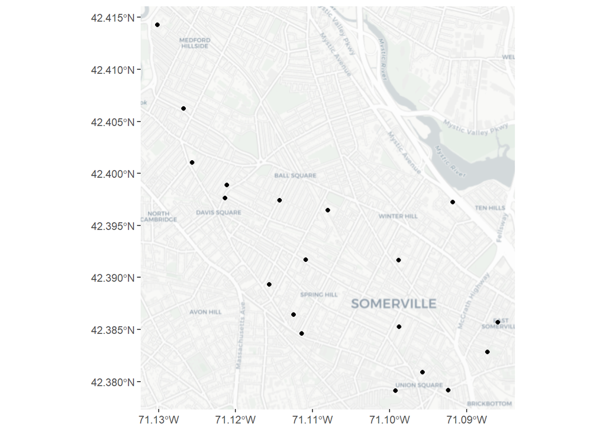

```r
ggplot(polls) +
  annotation_map_tile(type = "cartolight",
                      zoomin = -1) +
  geom_sf()
```

# Generate a grid

I’ll start by generating a grid of points that covers the area within a half mile of the Somerville boundary. Grid points will be 500 feet apart from one another. Since I want to use these to generate a travel time matrix, I’ll need to create an id column.

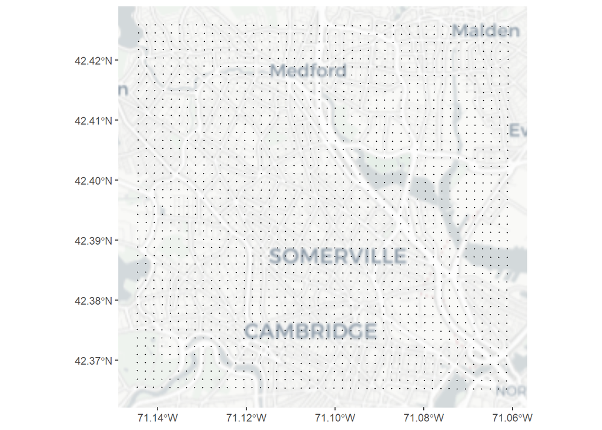

```r
MA_st_plane <- "+proj=lcc +lat_1=42.68333333333333 +lat_2=41.71666666666667 +lat_0=41 +lon_0=-71.5 +x_0=200000.0001016002 +y_0=750000 +ellps=GRS80 +towgs84=0,0,0,0,0,0,0 +to_meter=0.3048006096012192 +no_defs"

grid_points <- places(state = "MA") %>%
  filter(NAME == "Somerville") %>%
  st_transform(MA_st_plane) %>%
  st_buffer(dist = 2640) %>%
  st_make_grid(cellsize = 500,
               what = "corners") %>%
  st_as_sf() %>%
  st_transform("WGS84")

grid_points <- grid_points %>%
  mutate(id = as.character(seq(1, length(grid_points$x), by = 1)))

ggplot(grid_points) +
  annotation_map_tile(type = "cartolight", zoomin = -1) +
  geom_sf(size = 0.25)
```

# Find shortest distance from grid to features

Now I can use r5r to find the shortest walking time from each point on the grid to the nearest polling place. If you have a lot of points, this could take a few minutes.

```r
my_core <- here("a5-files",
                "Examples",
                "networks") %>%
  setup_r5(verbose = FALSE)

walk_from_grid <- travel_time_matrix(my_core,
                                   origins = grid_points,
                                   destinations = polls,
                                   mode = "WALK",
                                   verbose = FALSE) %>%
  pivot_wider(names_from = toId,
              values_from = travel_time) %>%
  rowwise() %>%
  mutate(min_time = min(c_across(-fromId),na.rm = TRUE)) %>%
  select(fromId, min_time) %>%
  rename(id = fromId)

grid_points <- grid_points %>%
  left_join(walk_from_grid)

stop_r5()
```

# Intermediate map

Here’s a quick map to show how walk time to the nearest polling place varies across your grid. I’m log-transforming the color scale so that the variation close to the polling locations in more visible.

```
## Zoom: 12
```

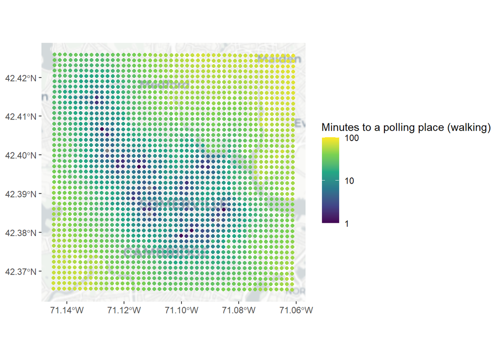

```r
ggplot(grid_points) +
  annotation_map_tile(type = "cartolight", zoomin = -1) +
  geom_sf(aes(color = min_time)) +
  scale_color_viridis_c(trans = "log",
                        name = "Minutes to a polling place (walking)",
                        breaks = c(1, 10, 100),
                        limits = c(1, 100))
```

# Interpolate points

To generate isochrones from those points, I’ll need to interpolate them to a grid matrix.

```r
# create variables with latitude/longitude coordinates
grid_points <- grid_points %>%
  mutate(lon = st_coordinates(.)[,1],
         lat = st_coordinates(.)[,2])

interp <- interp(grid_points$lon,
                 grid_points$lat,
                 grid_points$min_time)
```

# Generate isochrones

Now I can use the `isobands()` function to generate a set of isochrones for the area within a ten-minute walk of a polling place.

```
## Zoom: 14
```

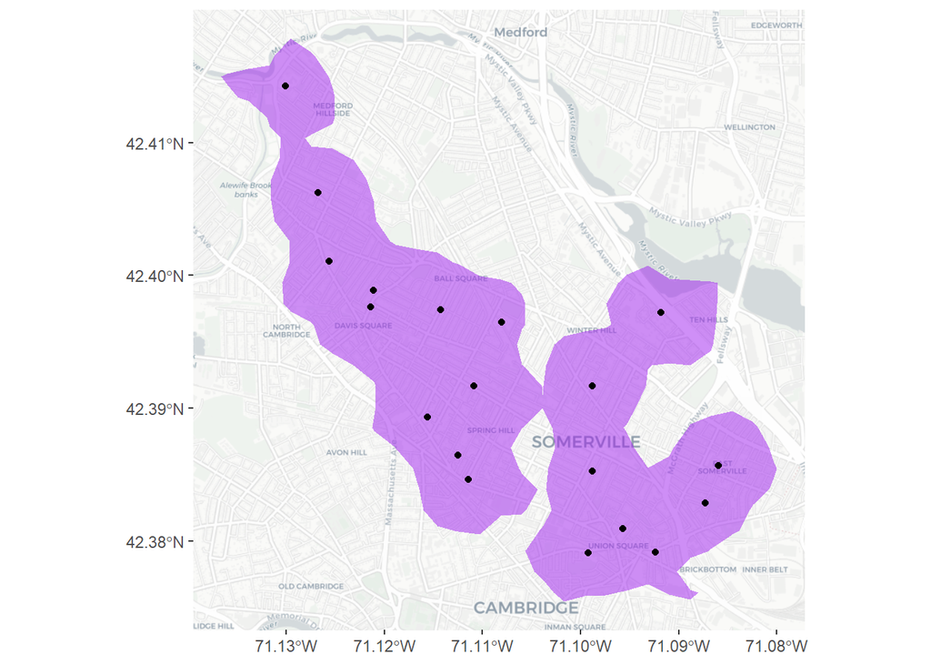

```r
isochrones <- isobands(x = interp$x,
                       y = interp$y,
                       z = t(interp$z),
                       levels_low = 0,
                       levels_high = 10) %>%
  iso_to_sfg()

iso_poly <- st_sf(level = 1:length(isochrones),
                  geometry = st_sfc(isochrones)) %>%
  st_set_crs("WGS84")

ggplot() +
 annotation_map_tile(type = "cartolight", zoomin = 0) +
  geom_sf(data = iso_poly,
          color = NA,
          fill = "purple",
          alpha = 0.5) +
  geom_sf(data = polls)
```